# Variable selection in topic models: Alex Bird Data

Kushal K Dey

December 27, 2015

## Background

We apply the variable selection method on real data. We first focus on the bird abundance data in Himalayas, which we are collaborating on with Alex White and Trevor Price.

## Data Pre-processing

```r
data=read.csv("../external_data/Himalayan_grid_matrix.csv",header=TRUE);

counts=as.matrix(data[,-1]);

rownames(counts)=data[,1];

new_data1 <- data.frame(read.csv('../external_data/MohanGrids.csv'));
new_data2 <- data.frame(read.csv('../external_data/MohanGrids2.csv'));

bird_species <- union(as.vector(colnames(counts)), union(as.vector(new_data1[,1]), as.vector(new_data2[,1])));

new_data <- matrix(0,dim(counts)[1]+3,length(bird_species));
new_data[1,match(new_data1[,1],bird_species)]=new_data1[,2];
new_data[2,match(new_data1[,1],bird_species)]=new_data1[,3];
new_data[3,match(new_data2[,1],bird_species)]=new_data2[,2];
new_data[4:(dim(counts)[1]+3),match(colnames(counts),bird_species)]=counts;

new_counts <- as.matrix(new_data);

rownames(new_counts) <- c(c("U1","U2","MA1"),rownames(counts));
colnames(new_counts) <- bird_species;
new_counts <- new_counts[-(1:3),];
```

## Topic model without variable selection

We first apply the topic model without variable selection pre-processing.

```r
metadata=read.csv("../external_data/Himalayan_grid_metadata.csv",header=TRUE);
elevation_metadata=metadata$Elevation[match(rownames(new_counts),metadata[,1])];

east_west_dir = metadata$WorE[match(rownames(new_counts),metadata[,1])];

library(maptpx)
system.time(Topic_clus <- topics(new_counts, K=2,tol=0.01));
```

```
##
## Estimating on a 35 document collection.
## Fitting the 2 topic model.
## log posterior increase: 281.45, 0.15, 0.96, 48.27, 0.11, 0.03, done.
```

```
##    user  system elapsed
##   0.042   0.002   0.043
```

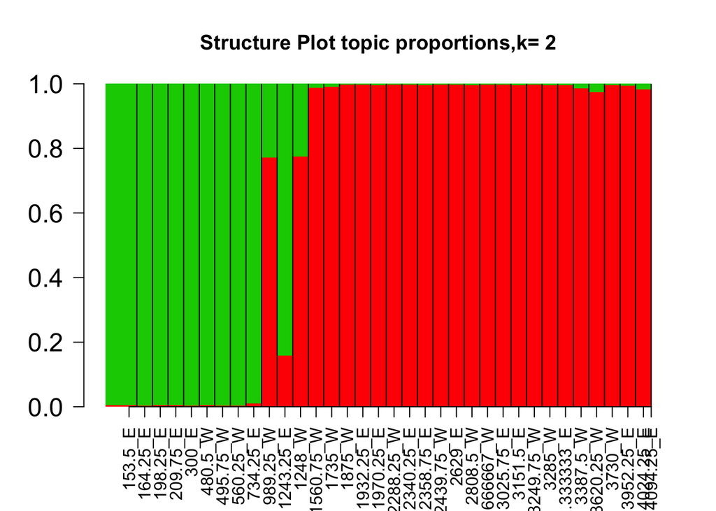

```r
K=2
barplot(t(Topic_clus$omega[order(elevation_metadata),]),col=2:(K+1),axisnames=F,space=0,border=NA,main="",las=1,ylim=c(0,1),cex.axis=1.5,cex.main=1.4)
title(main=paste("Structure Plot topic proportions,k=",K))
combo_patch_dir = paste0(elevation_metadata,"_",east_west_dir);
combo_patch_dir_ordered = combo_patch_dir[order(elevation_metadata)];

match_labs=match(unique(combo_patch_dir_ordered),combo_patch_dir_ordered);
match_labs_suffix=c(match_labs[2:length(unique(combo_patch_dir_ordered))],35);
match_labs_prefix=match_labs[1:(length(unique(combo_patch_dir_ordered)))];
labs=match_labs_prefix + 0.5*(match_labs_suffix - match_labs_prefix);

axis(1,at=labs,unique(combo_patch_dir_ordered),las=2);
abline(v=match_labs[2:length(match_labs)]);
```

## Topic model with variable selection

### Mean centering

We mean center the rows and the columns.

```r
data_norm1 <- apply(new_counts,2,function(x) return(x-mean(x)));
data_norm2 <- apply(data_norm1, 1, function(x) return(x-mean(x)));
```

### Penalized matrix decomposition

Then we perform factor analysis on the genes.

```r
library(PMA)
pmd1 <- PMD(data_norm2, type="standard", K=2, niter=50);
```

```
## 12345678910111213141516171819202122232425262728293031
## 1234567891011121314151617181920212223242526272829303132333435363738394041424344454647484950
```

### Factor loadings explore

We plot the barplot of the factor loadings, colors representing the two factors.

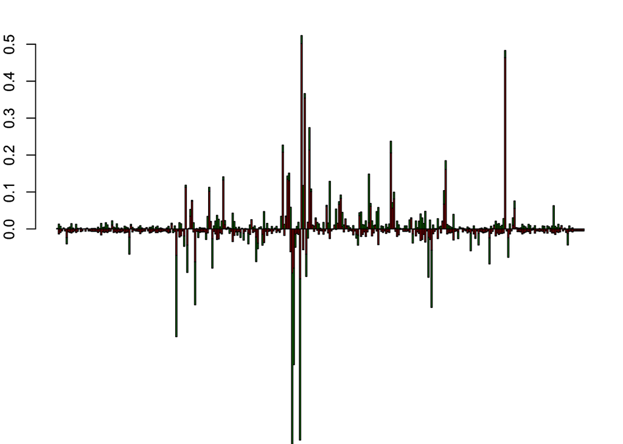

```r
pos_u <- apply(pmd1$u, c(1,2), function(x) return (max(x,0)))
neg_u <- apply(pmd1$u, c(1,2), function(x) return (min(x,0)))

par(mar=c(12,2,2,1))
barplot(t(pos_u), col=2:(K+1))
barplot(t(neg_u), col=2:(K+1), add=TRUE)
```

### Shrinking factor loadings

The sum of squared values of the columns of $u$ matrix from *PMD()* fit is 1 by definition. Check here

```r
apply(pmd1$u,2,function(x) return(sqrt(sum(x^2))))
```

```
## [1] 1 1
```

We assume that all the genes contribute equally to this variance or standard deviation of $1$ in the $u$ matrix and we assume the variance to be $1/G$, whhere $G$ is the total number of genes.

```r
library(ashr)
shrunk_u <- suppressWarnings(apply(pmd1$u, 2, function(x) return(ash(x,sqrt(1/length(x)))$PosteriorMean)));
```

```
## Due to absence of package REBayes, switching to EM algorithm
## Due to absence of package REBayes, switching to EM algorithm
```

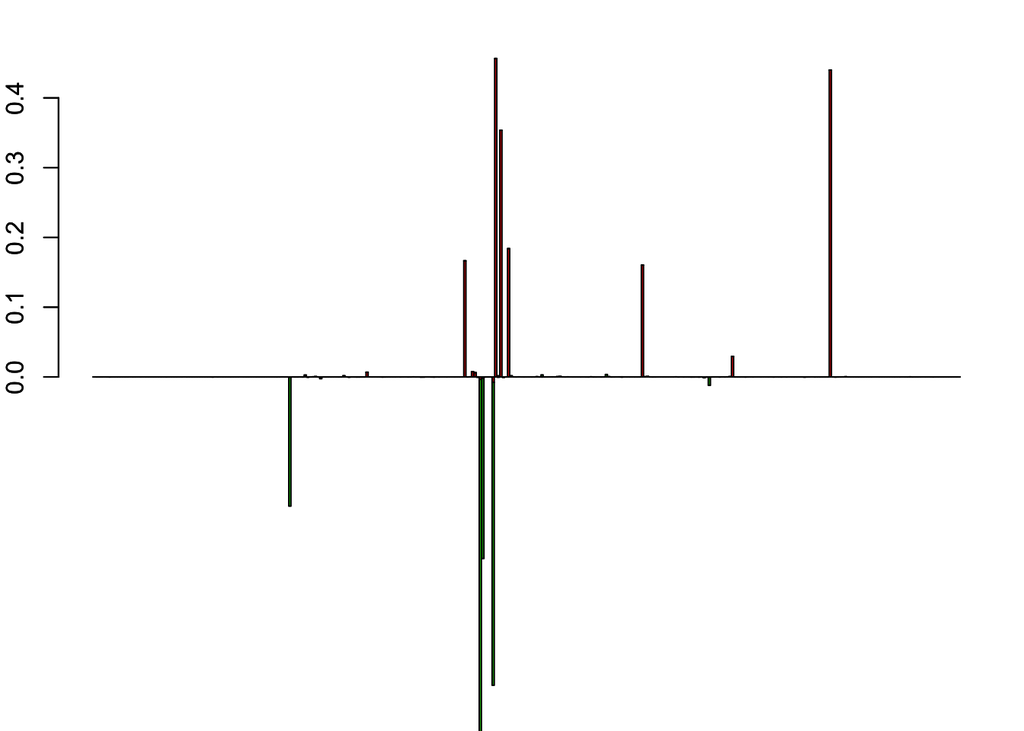

```r
pos_shrunk_u <- apply(shrunk_u, c(1,2), function(x) return (max(x,0)))
neg_shrunk_u <- apply(shrunk_u, c(1,2), function(x) return (min(x,0)))

par(mar=c(12,2,2,1))
barplot(t(pos_shrunk_u), col=2:3)
barplot(t(neg_shrunk_u), col=2:3, add=TRUE)
```

### Topic model fit on selected species (threshold 0.0001)

```r
ss_loadings <- apply(shrunk_u,1,function(x) return(sqrt(sum(x^2))))
which(ss_loadings > 1e-04)
```

```
##  [1]  47  77  83  84  86  87  89  98 100 103 107 113 128 129 133 145 147
## [18] 148 149 150 151 152 156 157 158 159 160 162 163 173 175 179 181 182
## [35] 194 195 200 201 206 214 215 216 233 234 236 238 240 248 249 254 265
## [52] 277 287 289 293 318
```

We now perform topic model on the selected genes.

```r
vs_counts <- new_counts[,which(ss_loadings > 1e-04)];
system.time(Topic_clus <- topics(vs_counts, K=2,tol=0.01));
```

```
##
## Estimating on a 35 document collection.
## Fitting the 2 topic model.
## log posterior increase: 165.59, 12.67, done.
```

```
##    user  system elapsed
##   0.015   0.000   0.015
```

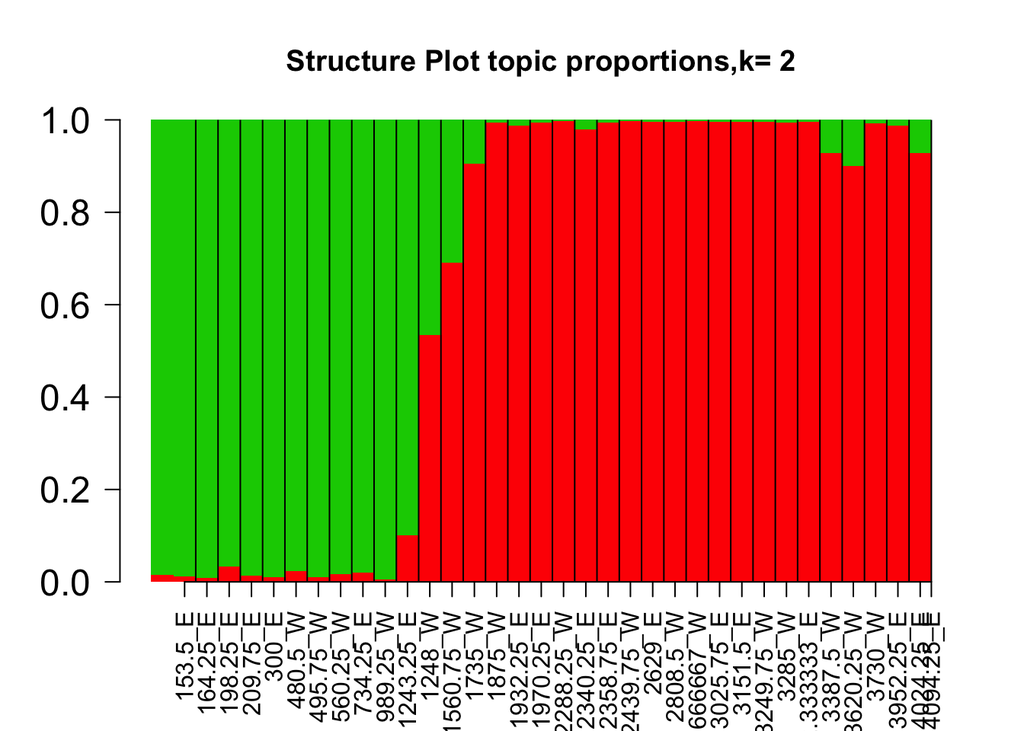

```r
K <- 2;
barplot(t(Topic_clus$omega[order(elevation_metadata),]),col=2:(K+1),axisnames=F,space=0,border=NA,main="",las=1,ylim=c(0,1),cex.axis=1.5,cex.main=1.4)
title(main=paste("Structure Plot topic proportions,k=",K))
combo_patch_dir = paste0(elevation_metadata,"_",east_west_dir);
combo_patch_dir_ordered = combo_patch_dir[order(elevation_metadata)];

match_labs=match(unique(combo_patch_dir_ordered),combo_patch_dir_ordered);
match_labs_suffix=c(match_labs[2:length(unique(combo_patch_dir_ordered))],35);
match_labs_prefix=match_labs[1:(length(unique(combo_patch_dir_ordered)))];
labs=match_labs_prefix + 0.5*(match_labs_suffix - match_labs_prefix);

axis(1,at=labs,unique(combo_patch_dir_ordered),las=2);
abline(v=match_labs[2:length(match_labs)]);
```

### Topic model fit on selected species (threshold 0.00001)

```r
ss_loadings <- apply(shrunk_u,1,function(x) return(sqrt(sum(x^2))))
which(ss_loadings > 1e-05)
```

```
##   [1]   2   3   4   6   7   8   9  10  11  12  13  14  16  17  19  21  22
##  [18]  23  24  25  26  27  28  29  30  31  32  33  34  35  36  37  38  39
##  [35]  40  41  42  43  44  45  46  47  48  49  51  52  53  54  55  56  57
##  [52]  58  59  60  61  62  63  64  65  66  67  68  69  70  71  72  73  74
##  [69]  75  76  77  78  79  80  81  82  83  84  86  87  88  89  90  91  92
##  [86]  93  94  95  96  97  98  99 100 101 102 103 104 105 106 107 108 111
## [103] 112 113 114 115 116 117 118 120 121 123 124 125 126 127 128 129 130
## [120] 132 133 134 135 136 137 138 139 141 142 143 144 145 146 147 148 149
## [137] 150 151 152 153 154 155 156 157 158 159 160 161 162 163 164 165 166
## [154] 167 168 169 170 171 172 173 174 175 176 178 179 180 181 182 183 184
## [171] 185 186 187 188 189 190 191 192 193 194 195 196 197 198 199 200 201
## [188] 202 203 204 205 206 208 209 210 211 212 213 214 215 216 217 218 219
## [205] 222 223 224 225 226 227 228 230 231 232 233 234 235 236 237 238 239
## [222] 240 241 242 244 245 246 247 248 249 250 251 252 253 254 255 256 257
## [239] 260 262 263 264 265 266 267 268 269 270 271 272 273 274 275 276 277
## [256] 278 279 280 281 282 283 284 285 286 287 288 289 290 291 292 293 294
## [273] 295 296 297 298 299 300 301 302 303 306 307 308 309 310 311 312 313
## [290] 314 316 317 318 319 320 321 322 323 324 326 327 328 329 330 331 332
## [307] 333 334 335 336 337
```

We now perform topic model on the selected genes.

```r
vs_counts <- new_counts[,which(ss_loadings > 1e-05)];
system.time(Topic_clus <- topics(vs_counts, K=2,tol=0.01));
```

```
##
## Estimating on a 35 document collection.
## Fitting the 2 topic model.
## log posterior increase: 285.06, 0.03, 0.06, 0.75, 2.64, 38.22, 0.22, 0.07, 1.77, 0.19, 0.04, done.
```

```
##    user  system elapsed
##   0.086   0.003   0.090
```

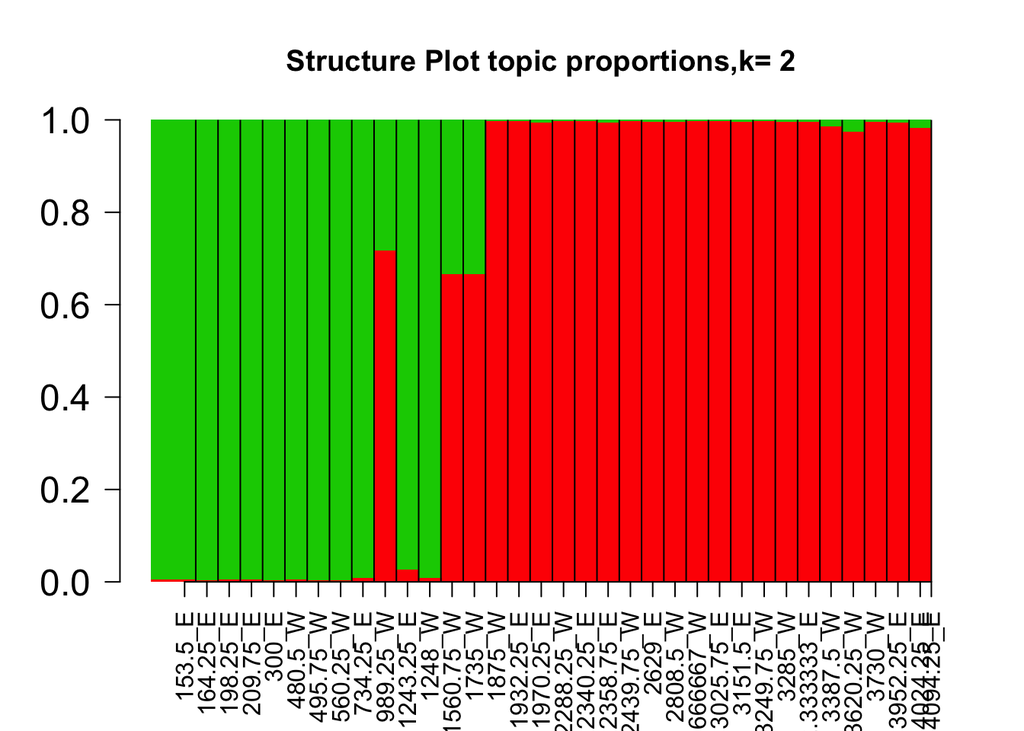

```r
K <- 2;
barplot(t(Topic_clus$omega[order(elevation_metadata),]),col=2:(K+1),axisnames=F,space=0,border=NA,main="",las=1,ylim=c(0,1),cex.axis=1.5,cex.main=1.4)
title(main=paste("Structure Plot topic proportions,k=",K))
combo_patch_dir = paste0(elevation_metadata,"_",east_west_dir);
combo_patch_dir_ordered = combo_patch_dir[order(elevation_metadata)];

match_labs=match(unique(combo_patch_dir_ordered),combo_patch_dir_ordered);
match_labs_suffix=c(match_labs[2:length(unique(combo_patch_dir_ordered))],35);
match_labs_prefix=match_labs[1:(length(unique(combo_patch_dir_ordered)))];
labs=match_labs_prefix + 0.5*(match_labs_suffix - match_labs_prefix);

axis(1,at=labs,unique(combo_patch_dir_ordered),las=2);
abline(v=match_labs[2:length(match_labs)]);
```

## Conclusion

The Structure plots after variable selection are slightly different from that without variable selection. Note that for threshold $0.0001$, we get a smooth continuous pattern in cluster memberships in the Structure plot. But that pattern is not seen for threshold $0.00001$, probably due to some false species been taken into account. We need to fix the threshold selection issue first. On a broad scale, the main patterns remain preserved from the Structure plot without variable selection to the one with variable selection.